# Geospatial Final Analysis

María José Osimani

2024-05-14

# Motivation and Research Question

A greater number of men view street harassment as humorous, romantic, or unimportant interactions (Jaggar & Rothenberg, 1984). Nevertheless, it inflicts severe emotional and psychological distress, reinforces gender inequality, restricts women’s liberty and mobility, and impacts self-esteem and sexuality. It serves as a mechanism of social control, maintaining male dominance in public spaces and reminding women of their vulnerability. (Bowman, 1993).

The are different determinants that affect street sexual harassment. Within the determinants related to the environment, evidence and testimonies relate harassment to street lighting (Hazelton, 2018; UN Women, 2013) and, moreover, street lighting has been shown to be related to economic growth in urban areas (Watson et al., 2023)

Therefore, understanding the profound effects of street harassment is essential for developing legal frameworks and social remedies that recognize and address the significant harm caused by harassment. Addressing this issue can lead to broader societal changes, promoting gender equality and reducing gender-based violence and discrimination.

I this sense, using data from Santiago, Chile, I am interested to answer what proportion of women have experienced street harassment in each municipality of Santiago and if it is this spatially correlated.

# Data

For the analysis I use data from the Survey on Violence against Women in the Sphere of Domestic Violence and in Other Settings (ENVIF-VCM) applied in Chile, which aims to obtain relevant information on the magnitude and characteristics of gender-based violence affecting women in urban areas at national and regional level, in order to guide prevention and control policies in these areas (Subsecretaría de Prevención del Delito & Ministerio del Interior y Seguridad Pública, 2020).

I consider the cases from Chile’s capital city, Santiago. To get a relevant sample size I use two rounds of the survey, 2017 and 2020. The survey is not longitudinal but cross-sectional, therefore, it is assumed that there are no repeated individuals in both surveys.

Additionally, for the spatial description and analysis, I use shape data that includes municipalities in Santiago of Chile but just populated urban areas, getting 36 observations (municipalities).

# Methods

The evaluation methods consist of a descriptive analysis showing the proportion of women surveyed who have experienced harassment, disaggregated by municipality in the city of Santiago.

Then, a spatial autocorrelation analysis is performed with a Moran’s I test. First globally, to identify a correlation indicator, and then locally, identifying local clusters to distinguish the areas with the highest degree of correlation.

```r
library(tidyverse)
library(dplyr)
library(haven)
library(sf)
library(terra)
library(tmap)
library(spdep)
library(broom)
library(kableExtra)
library(knitr)
library(table1)

setwd("C:/Users/majos/Documents/COTE/3. Hertie - MPP/SEM IV/Geospatial Analysis for Data Science/Poster")

#Loading survey data
envif2020 <- read_sav("Final ENVIF 2020 (Muestra Total)_v3.sav") %>%
  filter(region == 13) %>%
  select(comuna, edad, GSE_REC,
    p70_1,p71_1,p72_1,p73_1,p74_1_O1,p74_1_O2,p74_1_O3,p70_2,p71_2,p72_2,p73_2,
    p74_2_O1,p74_2_O2,p74_2_O3,p70_3,p71_3,p72_3,p73_3,p74_3_O1,p74_3_O2,
    p74_3_O3,p70_4,p71_4,p72_4,p73_4,p74_4_O1,p74_4_O2,p74_4_O3,p70_5,p71_5,
    p72_5,p73_5,p74_5_O1,p74_5_O2,p74_5_O3) %>%
  rename(cod_comuna = comuna) %>%
  mutate(cod_comuna = as.factor(cod_comuna))

envif2017 <- read_sav("BBDD_VIF (2017).sav") %>%
  filter(REGION_R == 13)

envif2017 <- envif2017 %>%
  mutate(p74_1_O1 = ifelse(P96_A == 1, 1, 2),
         p74_1_O2 = ifelse(P96_A == 2, 1, 2),
         p74_1_O3 = ifelse(P96_A == 3, 1, 2),
         p74_2_O1 = ifelse(P96_B == 1, 1, 2),
         p74_2_O2 = ifelse(P96_B == 2, 1, 2),
         p74_2_O3 = ifelse(P96_B == 3, 1, 2),
         p74_3_O1 = ifelse(P96_C == 1, 1, 2),
         p74_3_O2 = ifelse(P96_C == 2, 1, 2),
         p74_3_O3 = ifelse(P96_C == 3, 1, 2),
         p74_4_O1 = ifelse(P96_D == 1, 1, 2),
         p74_4_O2 = ifelse(P96_D == 2, 1, 2),
         p74_4_O3 = ifelse(P96_D == 3, 1, 2),
         p74_5_O1 = ifelse(P96_E == 1, 1, 2),
         p74_5_O2 = ifelse(P96_E == 2, 1, 2),
         p74_5_O3 = ifelse(P96_E == 3, 1, 2)) %>%
  rename(p70_1=P92_A, p71_1=P93_A, p72_1=P94_A, p73_1=P95_A,
         p70_2=P92_B, p71_2=P93_B, p72_2=P94_B, p73_2=P95_B,
         p70_3=P92_C, p71_3=P93_C, p72_3=P94_C, p73_3=P95_C,
         p70_4=P92_D, p71_4=P93_D, p72_4=P94_D, p73_4=P95_D,
         p70_5=P92_E, p71_5=P93_E, p72_5=P94_E, p73_5=P95_E,
         edad = EDAD_O)

envif2017 <- envif2017 %>%
  mutate(comuna =
           ifelse(COMUNA == "BUIN", 13402,
           ifelse(COMUNA == "LAMPA", 13302,
           ifelse(COMUNA == "MACUL", 13118,
           ifelse(COMUNA == "MAIPÚ", 13119,
           ifelse(COMUNA == "ÑUÑOA", 13120,
           ifelse(COMUNA == "PAINE", 13404,
           ifelse(COMUNA == "RENCA", 13128,
           ifelse(COMUNA == "COLINA", 13301,
           ifelse(COMUNA == "TILTIL", 13303,
           ifelse(COMUNA == "CONCHALÍ", 13104,
           ifelse(COMUNA == "LA REINA", 13113,
           ifelse(COMUNA == "LO PRADO", 13117,
           ifelse(COMUNA == "PEÑAFLOR", 13605,
           ifelse(COMUNA == "PUDAHUEL", 13124,
           ifelse(COMUNA == "RECOLETA", 13127,
           ifelse(COMUNA == "SANTIAGO", 13101,
           ifelse(COMUNA == "VITACURA", 13132,
           ifelse(COMUNA == "CERRILLOS", 13102,
           ifelse(COMUNA == "EL BOSQUE", 13105,
           ifelse(COMUNA == "LA GRANJA", 13111,
           ifelse(COMUNA == "LO ESPEJO", 13116,
           ifelse(COMUNA == "MELIPILLA", 13501,
           ifelse(COMUNA == "PEÑALOLEN", 13122,
           ifelse(COMUNA == "QUILICURA", 13125,
           ifelse(COMUNA == "SAN RAMÓN", 13131,
           ifelse(COMUNA == "TALAGANTE", 13601,
           ifelse(COMUNA == "HUECHURABA", 13107,
           ifelse(COMUNA == "LA FLORIDA", 13110,
           ifelse(COMUNA == "LA PINTANA", 13112,
           ifelse(COMUNA == "LAS CONDES", 13114,
           ifelse(COMUNA == "SAN MIGUEL", 13130,
           ifelse(COMUNA == "CERRO NAVIA", 13103,
           ifelse(COMUNA == "PROVIDENCIA", 13123,
           ifelse(COMUNA == "PUENTE ALTO", 13201,
           ifelse(COMUNA == "SAN JOAQUÍN", 13129,
           ifelse(COMUNA == "LO BARNECHEA", 13115,
           ifelse(COMUNA == "SAN BERNARDO", 13401,
           ifelse(COMUNA == "INDEPENDENCIA", 13108,
           ifelse(COMUNA == "ISLA DE MAIPO", 13603,
           ifelse(COMUNA == "PADRE HURTADO", 13604,
           ifelse(COMUNA == "QUINTA NORMAL", 13126,
           ifelse(COMUNA == "CALERA DE TANGO", 13403,
           ifelse(COMUNA == "ESTACIÓN CENTRAL", 13106,
           ifelse(COMUNA == "SAN JOSÉ DE MAIPO", 13203,
           ifelse(COMUNA == "PEDRO AGUIRRE CERDA", 13121,
                  NA))))))))))))))))))))))))))))))))))))))))))))))

envif2017 <- envif2017 %>%
  select(comuna, edad, GSE_REC,
    p70_1,p71_1,p72_1,p73_1,p74_1_O1,p74_1_O2,p74_1_O3,p70_2,p71_2,p72_2,p73_2,
    p74_2_O1,p74_2_O2,p74_2_O3,p70_3,p71_3,p72_3,p73_3,p74_3_O1,p74_3_O2,
    p74_3_O3,p70_4,p71_4,p72_4,p73_4,p74_4_O1,p74_4_O2,p74_4_O3,p70_5,p71_5,
    p72_5,p73_5,p74_5_O1,p74_5_O2,p74_5_O3) %>%
  rename(cod_comuna = comuna) %>%
  mutate(cod_comuna = as.factor(cod_comuna))

envif = bind_rows(envif2017, envif2020)

saveRDS(envif, "envif.rds")

envif <- read_rds("envif.rds")

rm(envif2017, envif2020)
```

# Results

## Descriptives

the descriptive results show that 2 out of 5 women have suffered some form of street harassment, 34% have experienced verbal harassment or intimidation and 22% have experienced physical harassment.

```r
#Harassment rate
envif <- envif %>%
  mutate(verbharasstment =
           ifelse(p70_1 == 1 | p70_2 == 1, "Yes",
           ifelse(p70_1 != 1 | p70_2 != 1, "No", NA)),
         physharassment =
           ifelse(p70_3 == 1 | p70_4 == 1 | p70_5 == 1, "Yes",
           ifelse(p70_3 != 1 & p70_4 != 1 & p70_5 != 1, "No", NA)),
         harassment =
           ifelse(verbharasstment == "Yes" | physharassment == "Yes", "Yes",
           ifelse(verbharasstment != "Yes" & physharassment != "Yes", "No", NA)))

envif %>%
  janitor::tabyl(harassment) %>%
  knitr::kable(col.names = c("Verbal and/or physical harassment","N","Prop")) %>%
  kableExtra::kable_styling(full_width = FALSE)
```

| Verbal and/or physical harassment | N | Prop |
| --- | --- | --- |
| No | 1345 | 0.6004464 |
| Yes | 895 | 0.3995536 |

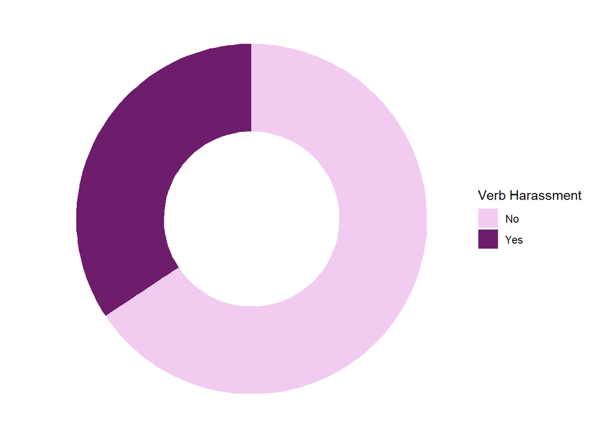

```r
verbhar <- envif %>%
  count(verbharasstment) %>%
  mutate(freq = n / sum(n),
         ymax = cumsum(freq),
         ymin = c(0, head(ymax, n=-1)))

ggplot(verbhar, aes(ymax=ymax, ymin=ymin, xmax=4, xmin=3, fill = verbharasstment)) +
  geom_rect() +
  coord_polar(theta="y") +
  xlim(c(2, 4)) +
  theme_void() +
  labs(fill = "Verb Harassment") +
  scale_fill_manual(values = c("Yes" = "#6D1D6B", "No" = "#F1CCF0"))
```

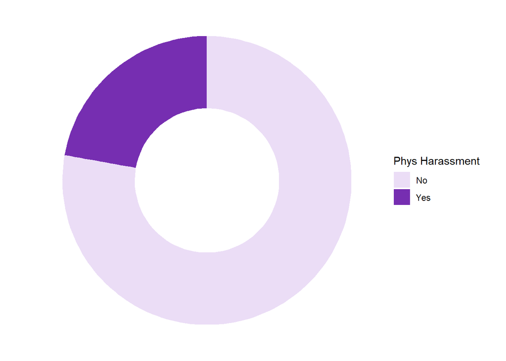

```r
physhar <- envif %>%
  count(physharassment) %>%
  mutate(freq = n / sum(n),
         ymax = cumsum(freq),
         ymin = c(0, head(ymax, n=-1)))

ggplot(physhar, aes(ymax=ymax, ymin=ymin, xmax=4, xmin=3, fill=physharassment)) +
  geom_rect() +
  coord_polar(theta="y") +
  xlim(c(2, 4)) +
  theme_void() +
  labs(fill = "Phys Harassment") +
  scale_fill_manual(values = c("Yes" = "#762EB1", "No" = "#EBDDF6"))
```

Among the women who mentioned having been harassed in the street, 45% mentioned having experienced it for the first time before the age of 14.

```r
envif <- envif %>%
  mutate(verbharasstment14 =
           ifelse(p71_1 == 1 | p71_2 == 1, "Yes",
           ifelse(p71_1 != 1 | p71_2 != 1, "No", NA)),
         physharassment14 =
           ifelse(p71_3 == 1 | p71_4 == 1 | p71_5 == 1, "Yes",
           ifelse(p71_3 != 1 & p71_4 != 1 & p71_5 != 1, "No", NA)),
         harassment14 =
           ifelse(verbharasstment14 == "Yes" | physharassment14 == "Yes", "Yes",
           ifelse(verbharasstment14 != "Yes" & physharassment14 != "Yes", "No", NA)))

envifhar <- envif %>%
  filter(harassment == "Yes")

envifhar %>%
  janitor::tabyl(harassment14) %>%
  knitr::kable(col.names = c("Verbal and/or physical harassment before 14 yo","N","Prop","Prop on responents")) %>%
  kableExtra::kable_styling(full_width = FALSE)
```

| Verbal and/or physical harassment before 14 yo | N | Prop | Prop on responents |
| --- | --- | --- | --- |
| No | 6 | 0.0067039 | 0.0148148 |
| Yes | 399 | 0.4458101 | 0.9851852 |
| NA | 490 | 0.5474860 | NA |

In addition, of the places where harassment occurs, 99% of harassed women mentioned having experienced it in their neighborhood, 98% on public transport and 100% on public roads.

```r
envif <- envif %>%
  mutate(neighbourhood =
           ifelse(p74_1_O1 == 1 | p74_2_O1 == 1 | p74_3_O1 == 1
                  | p74_4_O1 == 1 | p74_5_O1 == 1, "Yes",
           ifelse(p74_1_O1 != 1 & p74_2_O1 != 1 & p74_3_O1 != 1
                  & p74_4_O1 != 1 & p74_5_O1 != 1, "No", NA)),
         publictransport =
           ifelse(p74_1_O2 == 1 | p74_2_O2 == 1 | p74_3_O2 == 1
                  | p74_4_O2 == 1 | p74_5_O2 == 1, "Yes",
           ifelse(p74_1_O2 != 1 & p74_2_O2 != 1 & p74_3_O2 != 1
                  & p74_4_O2 != 1 & p74_5_O2 != 1, "No", NA)),
         streets =
           ifelse(p74_1_O3 == 1 | p74_2_O3 == 1 | p74_3_O3 == 1
                  | p74_4_O3 == 1 | p74_5_O3 == 1, "Yes",
           ifelse(p74_1_O3 != 1 & p74_2_O3 != 1 & p74_3_O3 != 1
                  & p74_4_O3 != 1 & p74_5_O3 != 1, "No", NA)))

envifhar <- envif %>%
  filter(harassment == "Yes")

neighbourhood <- round(prop.table(table(envif$neighbourhood)), 2)*100
publictransport <- round(prop.table(table(envif$publictransport)), 2)*100
street <- round(prop.table(table(envif$streets)), 2)*100
street <- rbind(0, street)

setting <- cbind(neighbourhood, publictransport)
setting <-  cbind(setting, street)

tidy(setting) %>%
knitr::kable(col.names =
               c("Neighbourhood", "Public transport", "Street"),
             caption = "Settings") %>%
kableExtra::kable_styling(full_width = FALSE)
```

Settings

| Neighbourhood | Public transport | Street |
| --- | --- | --- |
| 1 | 2 | 0 |
| 99 | 98 | 100 |

```r
rm(envifhar, verbhar, physhar)

# Managing survey data to merge with shape data
envif <- envif %>%
  mutate(muniharast =
           ifelse(harassment == "Yes" & (neighbourhood == "Yes" | streets == "Yes"), 1,
           ifelse(harassment == "No" | (neighbourhood != "Yes" | streets != "Yes"), 0, NA)))

envif <- envif %>%
  group_by(cod_comuna) %>%
  mutate(ncomuna = n(),
         comharassment = sum(muniharast, na.rm = T)) %>%
  ungroup() %>%
  mutate(propharast = round(comharassment / ncomuna, 2))

envif_unique <- envif %>%
  group_by(cod_comuna) %>%
  slice(1) %>%
  ungroup()
```

```r
# Loading shape data
chile <- read_sf("comunas.shp") %>%
  filter(codregion == 13)

urban <- read_sf("Areas_Pobladas.shp")

urbanstgo <- urban %>%
  rename(Comuna = comuna) %>%
  st_join(chile %>% select(Provincia), by = "Comuna") %>%
  filter(Provincia == "Santiago" | Comuna == "Puente Alto")

urbanstgo <- urbanstgo %>%
  mutate(cod_comuna =
           ifelse(Comuna == "Cerrillos", 13102,
           ifelse(Comuna == "Cerro Navia", 13103,
           ifelse(Comuna == "Conchalí", 13104,
           ifelse(Comuna == "El Bosque", 13105,
           ifelse(Comuna == "Estación Central", 13106,
           ifelse(Comuna == "Huechuraba", 13107,
           ifelse(Comuna == "Independencia", 13108,
           ifelse(Comuna == "La Cisterna", 13109,
           ifelse(Comuna == "La Florida", 13110,
           ifelse(Comuna == "La Granja", 13111,
           ifelse(Comuna == "La Pintana", 13112,
           ifelse(Comuna == "La Reina", 13113,
           ifelse(Comuna == "Lampa", 13302,
           ifelse(Comuna == "Las Condes", 13114,
           ifelse(Comuna == "Lo Barnechea", 13115,
           ifelse(Comuna == "Lo Espejo", 13116,
           ifelse(Comuna == "Lo Prado", 13117,
           ifelse(Comuna == "Macul", 13118,
           ifelse(Comuna == "Maipú", 13119,
           ifelse(Comuna == "Ñuñoa", 13120,
           ifelse(Comuna == "Padre Hurtado", 13604,
           ifelse(Comuna == "Pedro Aguirre Cerda", 13121,
           ifelse(Comuna == "Peñalolén", 13122,
           ifelse(Comuna == "Providencia", 13123,
           ifelse(Comuna == "Pudahuel", 13124,
           ifelse(Comuna == "Puente Alto", 13201,
           ifelse(Comuna == "Quilicura", 13125,
           ifelse(Comuna == "Quinta Normal", 13126,
           ifelse(Comuna == "Recoleta", 13127,
           ifelse(Comuna == "Renca", 13128,
           ifelse(Comuna == "San Bernardo", 13401,
           ifelse(Comuna == "San Joaquín", 13129,
           ifelse(Comuna == "San Miguel", 13130,
           ifelse(Comuna == "San Ramón", 13131,
           ifelse(Comuna == "Santiago", 13101,
           ifelse(Comuna == "Vitacura", 13132,
                  NA)))))))))))))))))))))))))))))))))))))

urbanstgo <- urbanstgo %>%
  mutate(cod_comuna = as.factor(cod_comuna)) %>%
  left_join(envif_unique %>%
              select(cod_comuna, comharassment, propharast), by = "cod_comuna") %>%
  distinct(cod_comuna, Localidad, .keep_all = TRUE)
```

The following figure presents the rate, by municipality in Santiago, of women who recognize having been sexually harassed in public, where it is possible to note a certain concentration of a higher proportion of women harassed in the street in the more central municipalities of the capital.

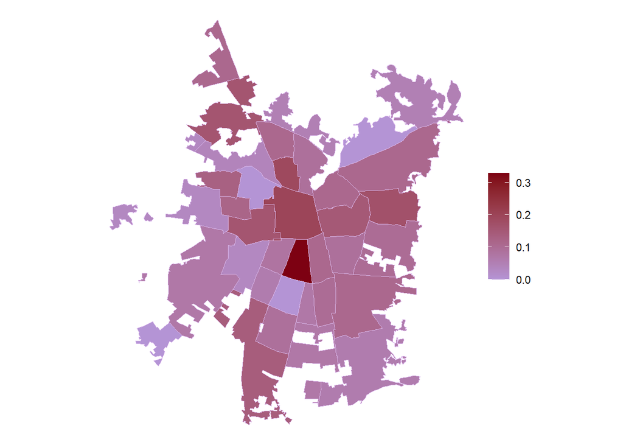

```r
ggplot() +
  geom_sf(data = urbanstgo, aes(fill = propharast), color = "#DCBAED") +
  theme_void() +
  scale_fill_gradient(low = "#B494D5", high = "#7D0112", name = NULL)
```